# Prosper loans

5 October 2017

##### This report explores a dataset containing 113,937 loans with 81 variables on each loan, including loan amount, borrower rate (or interest rate), current loan status, borrower income, etc. The source of the data is Prosper, or Prosper Marketplace, an online peer-to-peer lending company.

##### The detailed description of the variables can be found on this page: https://docs.google.com/spreadsheets/d/1gDyi_L4UvIrLTEC6Wri5nbaMmkGmLQBk-Yx3z0XDEtI/edit#gid=0

## Number of records and variables

```
## [1] 113937     81
```

##### After checking the dataset for duplicated keys and missing values, I noticed that:

##### - ListingKey has duplicated values. Some ids have all the fields duplicated with the same values,the only exception being the Prosper Score. I removed the duplicated records and kept only the first row for each id;

##### - the missing values are occuring especially before July 2009;

##### - ‘NC’ score category appears only before July 2009. We know that the scoring system was changed in July 2009.The Prosper Score will be an important feature in my analysis. So, I’m going to filter out records before July 2009;

##### In the end we are left with 83,982 records in the dataset.

```
## [1] 83982    83
```

```
##                    ListingKey    ListingNumber
##  00003546482094282EF90E5:    1   Min.   : 416275
##  00013542762124763F20254:    1   1st Qu.: 557061
##  00013592180058085D3AC05:    1   Median : 734179
##  000335337029714661FD4AD:    1   Mean   : 771240
##  0005353671687550573289D:    1   3rd Qu.: 975678
##  00053596416593761653B0E:    1   Max.   :1255725
##  (Other)                :83976
##                     ListingCreationDate  CreditGrade         Term
##  2012-10-20 12:21:46.333000000:    2           :83982   Min.   :12.00
##  2013-06-03 17:27:50.540000000:    2    A      :    0   1st Qu.:36.00
##  2009-07-13 18:01:24.347000000:    1    AA     :    0   Median :36.00
##  2009-07-13 18:04:40.220000000:    1    B      :    0   Mean   :42.46
##  2009-07-13 19:08:45.763000000:    1    C      :    0   3rd Qu.:60.00
##  2009-07-13 19:09:37.827000000:    1    D      :    0   Max.   :60.00
##  (Other)                      :83974    (Other):    0
##                  LoanStatus                  ClosedDate
##  Current              :55730                      :57990
##  Completed            :19651   2014-03-04 00:00:00:  105
##  Chargedoff           : 5336   2014-02-19 00:00:00:  100
##  Defaulted            : 1005   2014-02-11 00:00:00:   92
##  Past Due (1-15 days) :  800   2012-10-30 00:00:00:   81
##  Past Due (31-60 days):  361   2013-02-26 00:00:00:   78
##  (Other)              : 1099   (Other)            :25536
##   BorrowerAPR       BorrowerRate     LenderYield
##  Min.   :0.04583   Min.   :0.0400   Min.   :0.0300
##  1st Qu.:0.16361   1st Qu.:0.1359   1st Qu.:0.1259
##  Median :0.21945   Median :0.1875   Median :0.1775
##  Mean   :0.22694   Mean   :0.1963   Mean   :0.1863
##  3rd Qu.:0.29254   3rd Qu.:0.2574   3rd Qu.:0.2474
##  Max.   :0.42395   Max.   :0.3600   Max.   :0.3400
##
##  EstimatedEffectiveYield EstimatedLoss     EstimatedReturn
##  Min.   :-0.1827         Min.   :0.00490   Min.   :-0.18270
##  1st Qu.: 0.1160         1st Qu.:0.04240   1st Qu.: 0.07463
##  Median : 0.1616         Median :0.07240   Median : 0.09211
##  Mean   : 0.1689         Mean   :0.08042   Mean   : 0.09625
##  3rd Qu.: 0.2253         3rd Qu.:0.11200   3rd Qu.: 0.11710
##  Max.   : 0.3199         Max.   :0.36600   Max.   : 0.28370
##
```

[output cut: 193 more lines]

```
##  Min.   :0.000000           Min.   :    0.00            Min.   :   1.00
##  1st Qu.:0.000000           1st Qu.:    0.00            1st Qu.:   1.00
##  Median :0.000000           Median :    0.00            Median :  32.00
##  Mean   :0.008133           Mean   :    4.36            Mean   :  68.68
##  3rd Qu.:0.000000           3rd Qu.:    0.00            3rd Qu.:  98.00
##  Max.   :9.000000           Max.   :11000.00            Max.   :1189.00
##
##  ListingCreationDate2    Score
##  Min.   :2009-07-13   Length:83982
##  1st Qu.:2012-02-07   Class :character
##  Median :2013-03-20   Mode  :character
##  Mean   :2012-10-30
##  3rd Qu.:2013-10-23
##  Max.   :2014-03-10
##
```

## UNIVARIATE PLOTS SECTION

### 1. NUMBER OF LOANS

##### First, let’s see the evolution in time of the number of loans. For this I need to create new variables for month, year and month&year.I will extract this information from LoanOriginationDate variable.

#### 1.1 Number of loans by month and year.

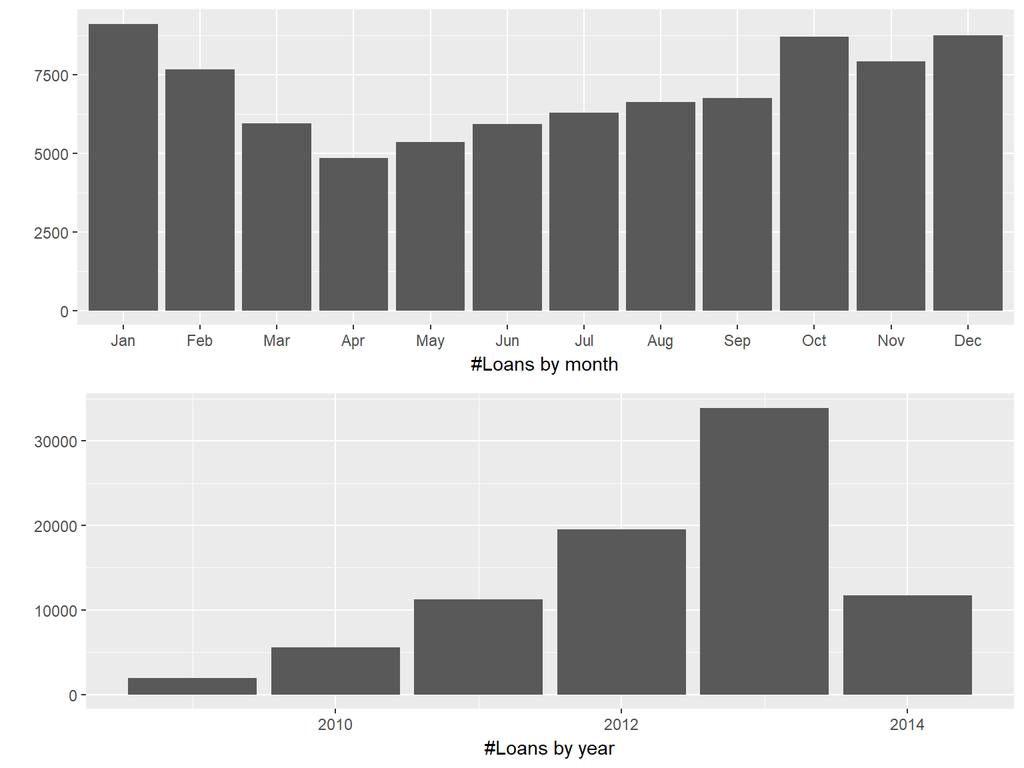

##### Number of loans are increasing by year. Years 2009 and 2014 don’t have data for all 12 months: we have data from July 2009 until March 2014.

##### We see more loans in the first and last months of the year. Is there a sesonality for loans? Are people borrowing more in January and December? Let’s plot the same thing, but facet wraped by year.

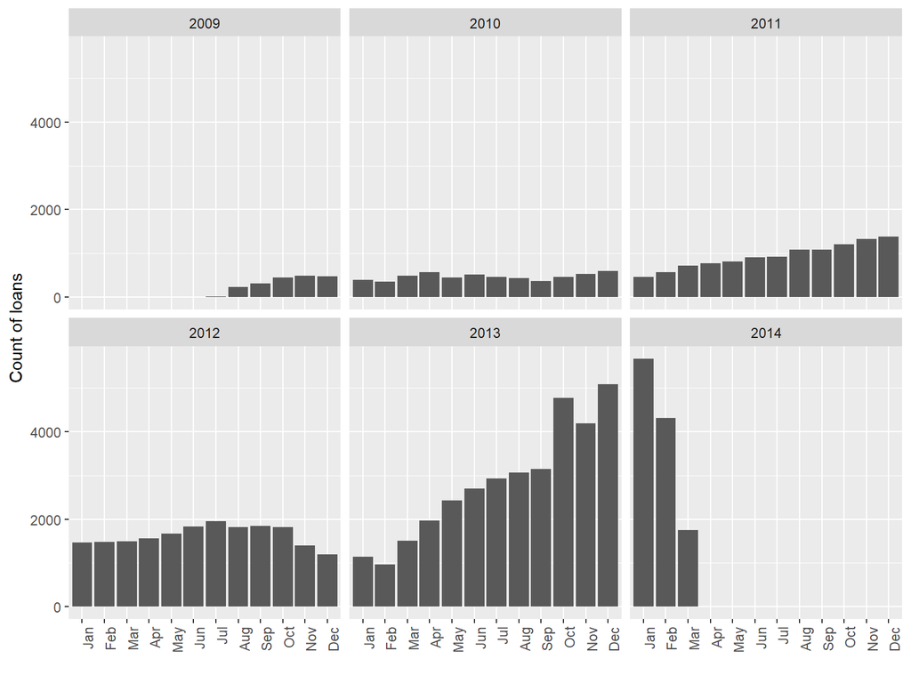

##### From this plot we see that loans are increasing over time, with high peaks in Oct-Dec 2013 and Jan 2014. There is actually no seasonality in data. The peaks in 2013 and 2014 are affecting the total loans distribution by month.

### 2. VALUES OF LOANS

##### Total amount of loans by year:

```
## # A tibble: 6 × 3
##   yearCreditDate value_loans no_loans
##            <dbl>       <int>    <int>
## 1           2009     8657561     1976
## 2           2010    26620674     5579
## 3           2011    75138013    11228
## 4           2012   153175116    19553
## 5           2013   357437822    33912
## 6           2014   139950560    11734
```

##### Summary:

```
##    Min. 1st Qu.  Median    Mean 3rd Qu.    Max.
##    1000    4000    7500    9061   13500   35000
```

##### Histogram:

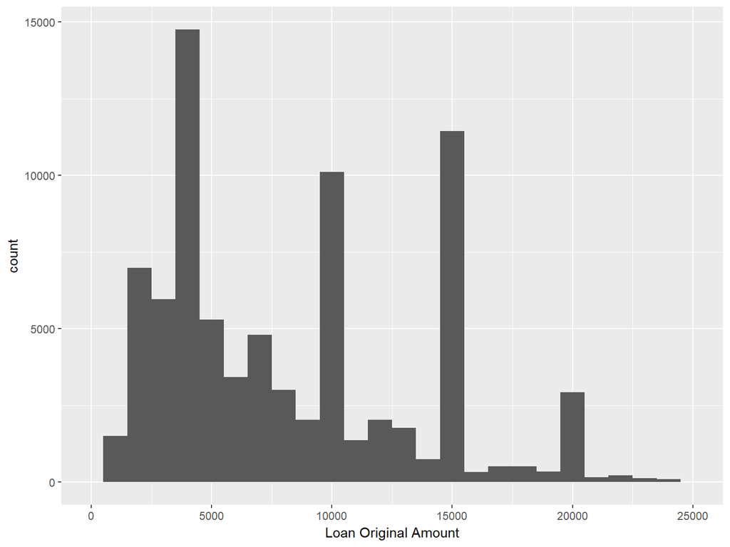

##### People preffer to borrow round values, like $4000,$10000,$15000,$20000 (in the histogram above we have high peaks for these values).

##### Summary loans by year:

```
## df_loans$yearCreditDate: 2009
##    Min. 1st Qu.  Median    Mean 3rd Qu.    Max.
##    1000    1500    3000    4381    5500   25000
## --------------------------------------------------------
## df_loans$yearCreditDate: 2010
##    Min. 1st Qu.  Median    Mean 3rd Qu.    Max.
##    1000    2000    3900    4772    6000   25000
## --------------------------------------------------------
## df_loans$yearCreditDate: 2011
##    Min. 1st Qu.  Median    Mean 3rd Qu.    Max.
##    2000    3800    5500    6692    8361   25000
## --------------------------------------------------------
## df_loans$yearCreditDate: 2012
##    Min. 1st Qu.  Median    Mean 3rd Qu.    Max.
##    2000    4000    5000    7834   11500   25000
## --------------------------------------------------------
## df_loans$yearCreditDate: 2013
##    Min. 1st Qu.  Median    Mean 3rd Qu.    Max.
##    2000    4000   10000   10540   15000   35000
## --------------------------------------------------------
## df_loans$yearCreditDate: 2014
##    Min. 1st Qu.  Median    Mean 3rd Qu.    Max.
##    2000    6600   10000   11930   15000   35000
```

##### Loan amount is increasing by year. In the last 2 years, 25% of the people borrowed more than $15000, compared to $6000 in 2010.

##### Boxplot loan amount per year:

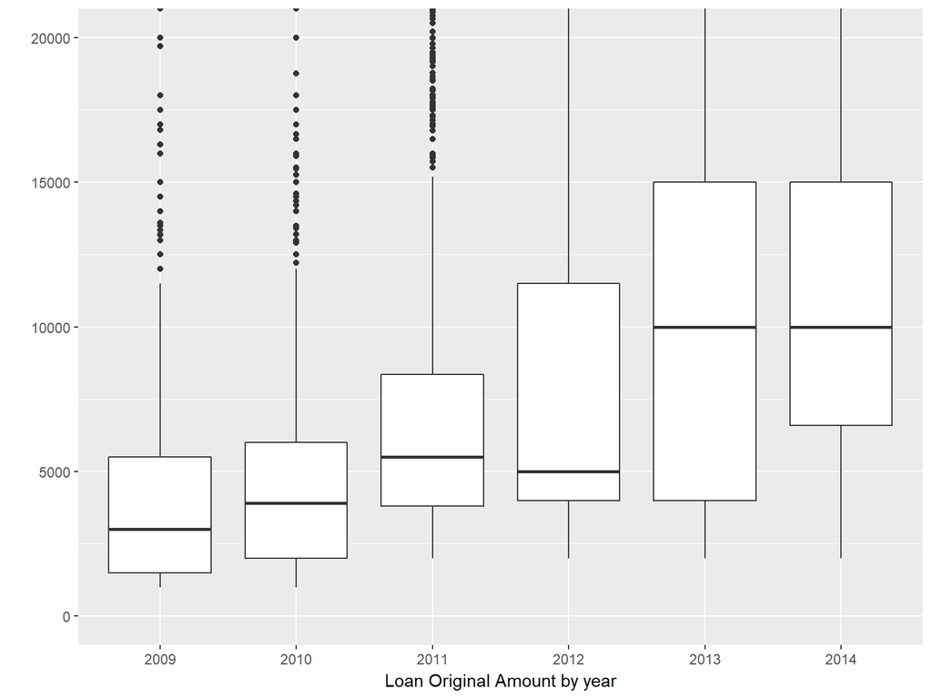

##### The total values and the median of the loans are increasing by year. In 2012, the median is very low, which means there were many loans of low values; 50% of the people borrowed less than $5000.

### 3. CREDIT SCORE

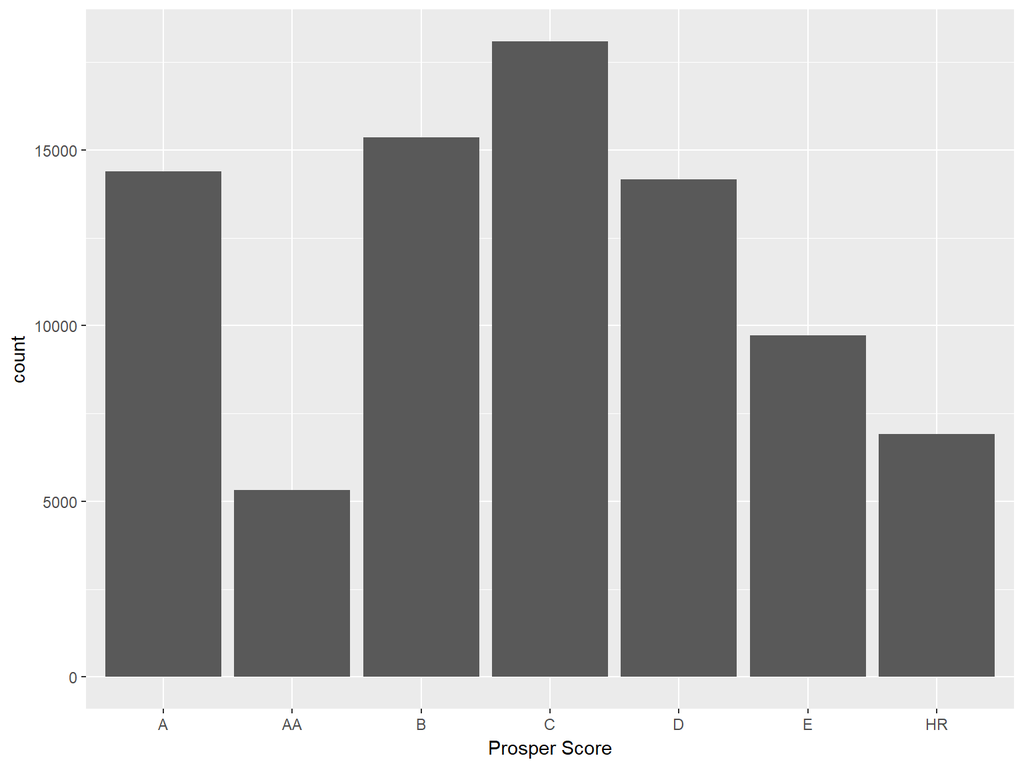

##### Prosper has many high value borrowers. A,B and C are the most frequent scores. Lets see if the scores changed over time.

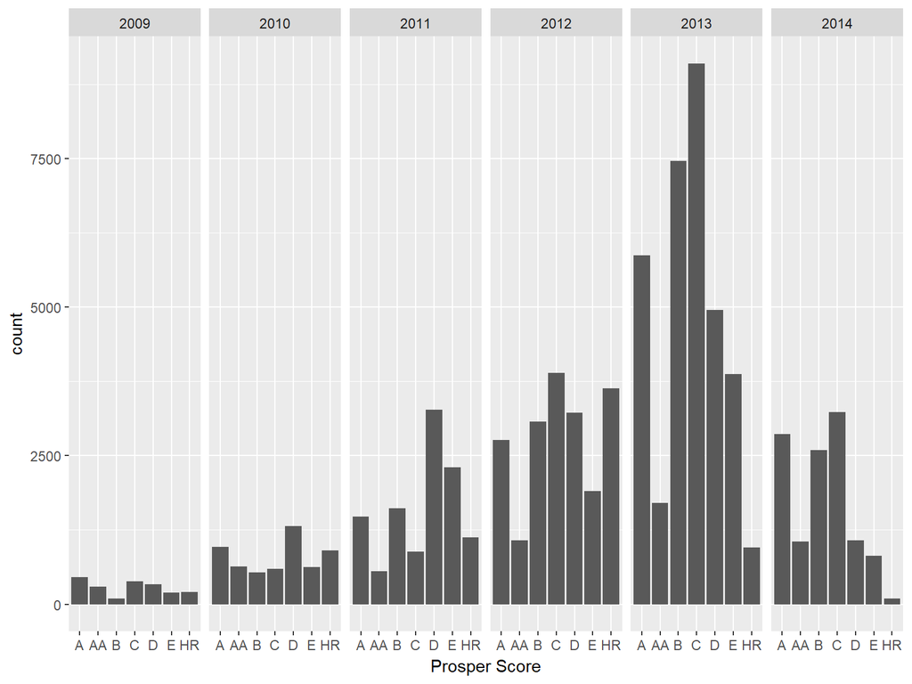

##### We see a descrease in E and D and increase in B and C scores. In 2012, there was a great increase of HR score. This could explain why the meadian of loans was so low in 2012, as we saw in a previous boxplot.

### 4. LOAN STATUS

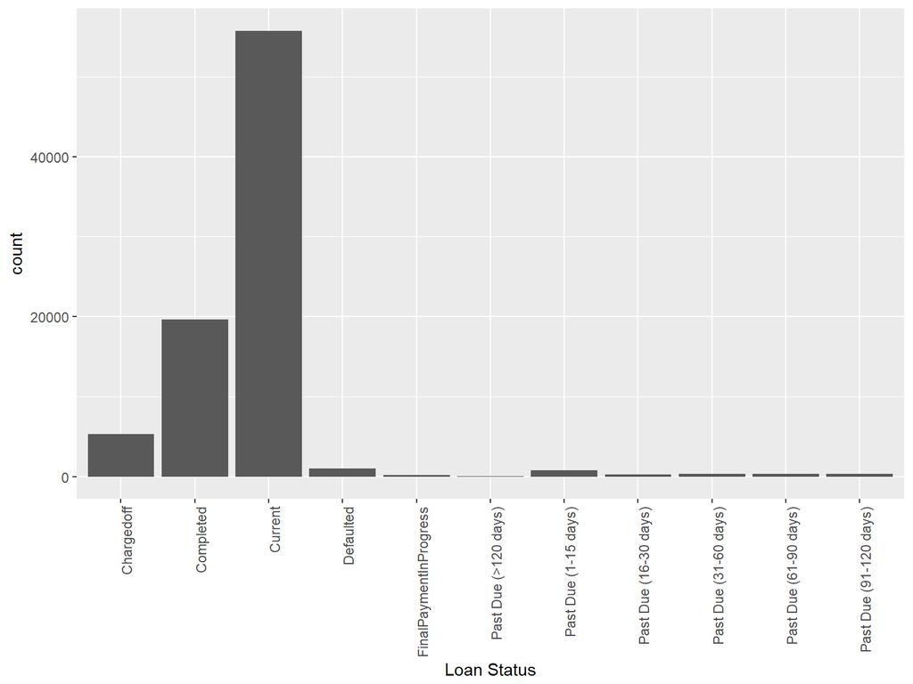

##### Most of the loans have ‘Current’ status. I need to create a new variable with the Past due categories grouped.

```
## # A tibble: 6 × 3
##           LoanStatus_rec     N        freq
##                    <chr> <int>       <dbl>
## 1             Chargedoff  5336 0.063537425
## 2              Completed 19651 0.233990617
## 3                Current 55730 0.663594580
## 4              Defaulted  1005 0.011966850
## 5 FinalPaymentInProgress   203 0.002417185
## 6                PastDue  2057 0.024493344
```

##### Plot the recoded loan status variable:

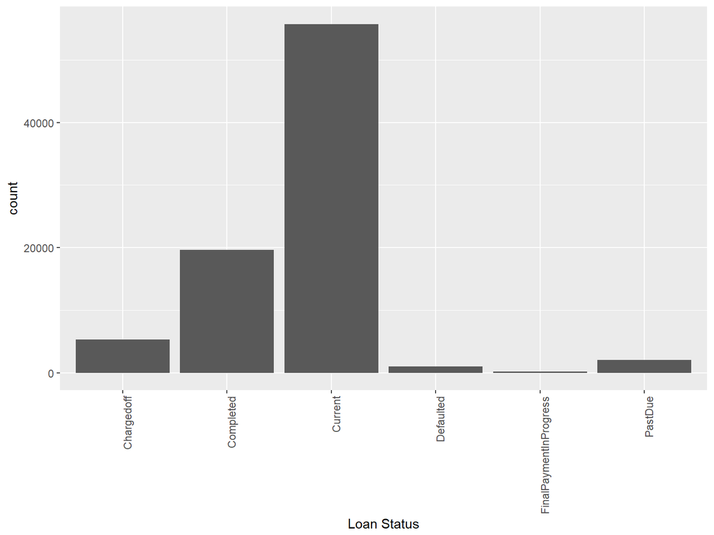

### 5. RATES

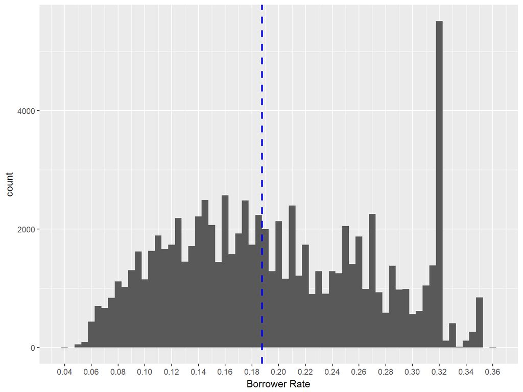

```
##    Min. 1st Qu.  Median    Mean 3rd Qu.    Max.
##  0.0400  0.1359  0.1875  0.1963  0.2574  0.3600
```

##### Borrowerrate has a peak around 0.32, value close to the maximun rate.Is this a normal value for the borrower rate? My guess is,this value has something to do with year 2012, when Prosper had many low loans in HR category.

##### Let’s see if this is true. First, let’s find the exact value where this peak happens.

```
##     mode
## 1 0.3177
```

##### This value is 0.3177.

##### Next let’s plot the 0.3177 BorrowerRate, facet warped by year.

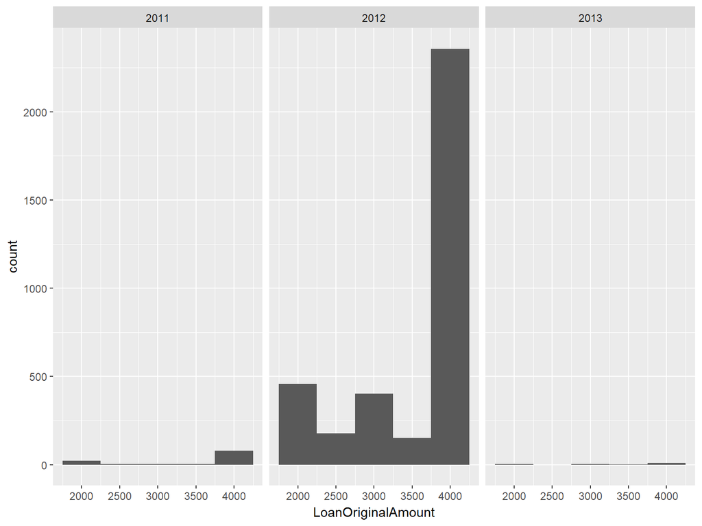

##### In 2012, there was a high amount of loans of $4000 with a borrower rate of 0.3177. Where they also in HR category ?

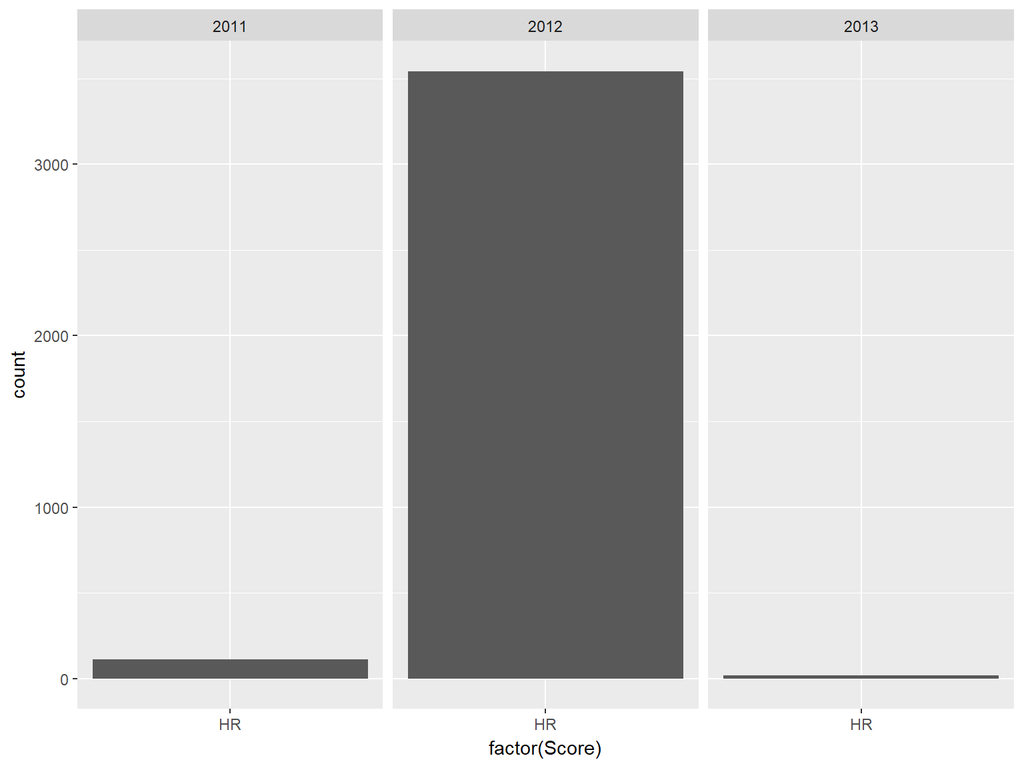

##### Yes, my intuition was correct. Borrower rate 0.3177 was applied to HR category.

##### One more curiosity: was this rate applied only in certain months of 2012?

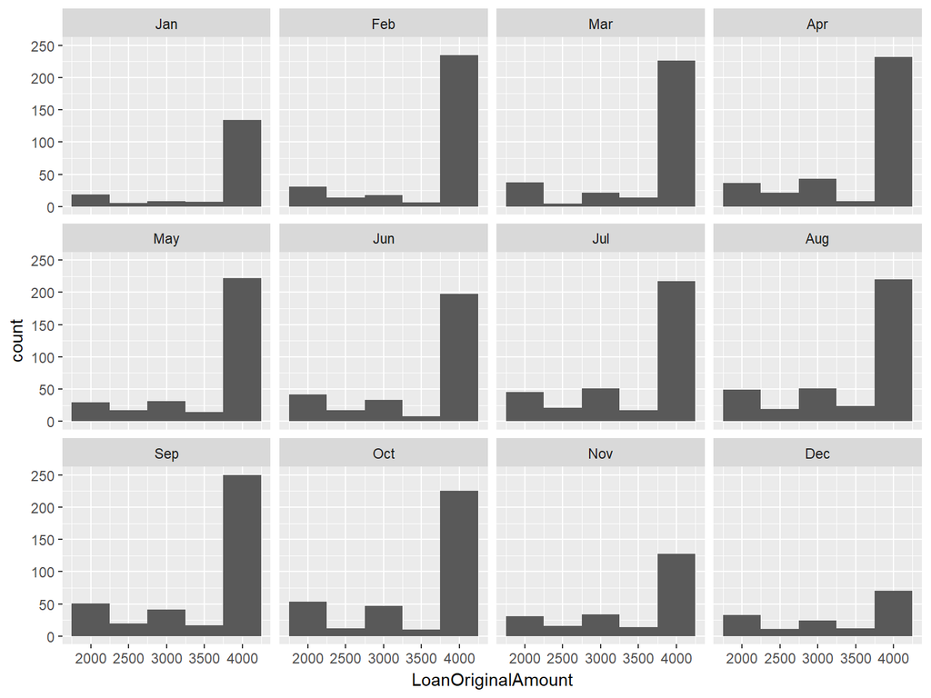

##### This rate is present in all the months of 2012, with a high decrease at the end of the year.

#### RATES - BOXPLOTS:

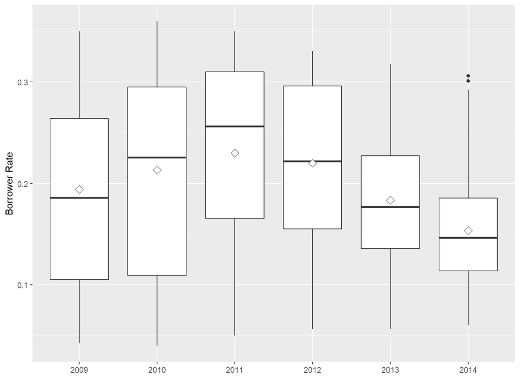

##### Borrower rates have an ascendent trend from 2009 to 2011 and start decreasing in 2012.

##### Let’s see if the borrower rate is influenced by Prosper Score?

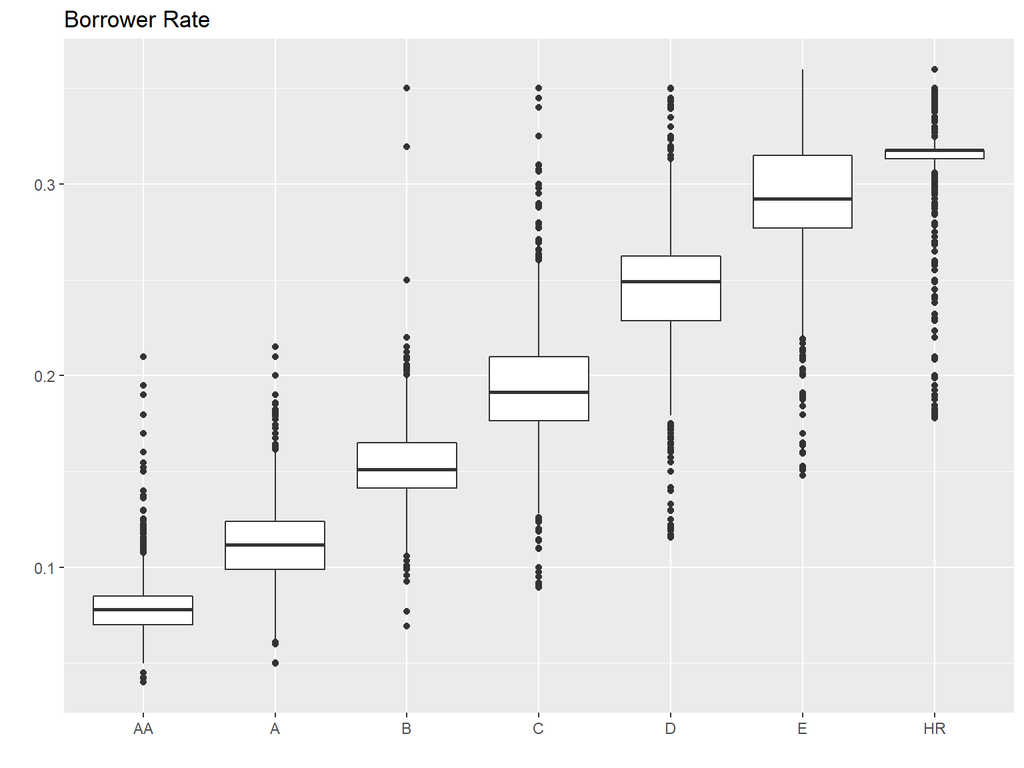

##### Clearly, the most valuable borrowers (AA category) have the lowest rates, while the risky ones have higher rates.

##### Rate increases by prosper score. There’s a high negative correlation of -0.95 between borrower rate and prosper score.

```
##
##  Pearson's product-moment correlation
##
## data:  ProsperRating..numeric. and BorrowerRate
## t = -912.61, df = 83980, p-value < 2.2e-16
## alternative hypothesis: true correlation is not equal to 0
## 95 percent confidence interval:
##  -0.9537173 -0.9524783
## sample estimates:
##        cor
## -0.9531018
```

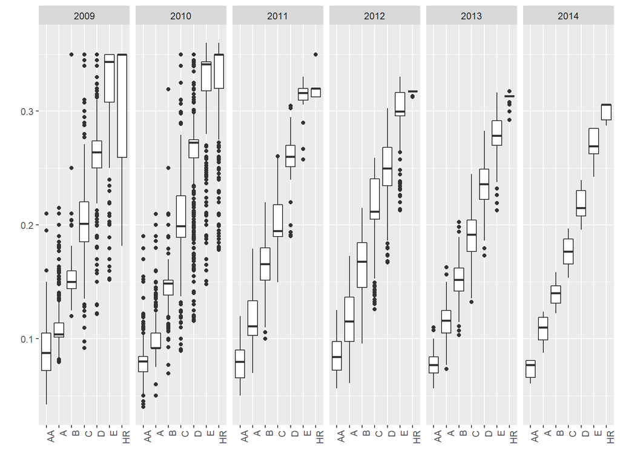

### 6. BORROWERS CHARACTERISTICS: EMPLOYMENT STATUS, Is Borrower Homeowner?, IncomeRange

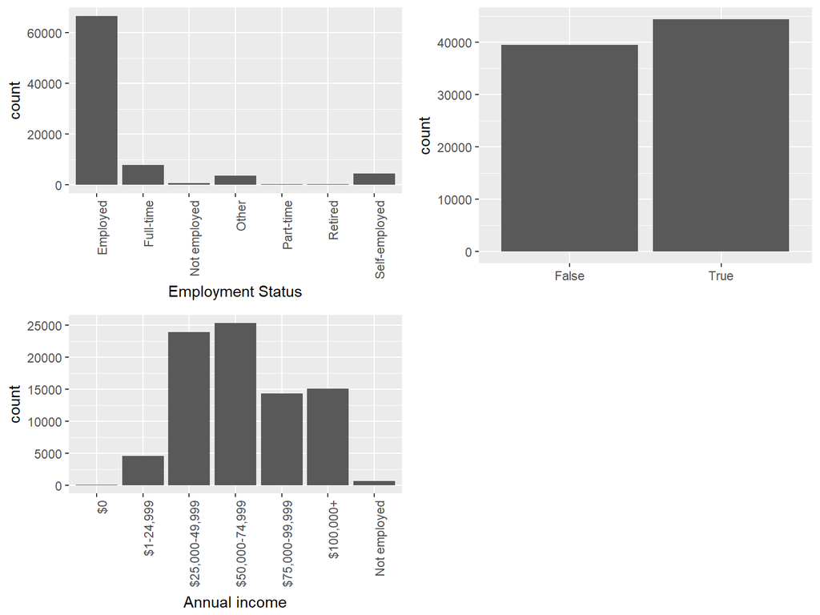

### 7. INCOME AND DEBT TO INCOME

##### Summary StatedMonthlyIncome:

```
##    Min. 1st Qu.  Median    Mean 3rd Qu.    Max.
##       0    3427    5000    5931    7083 1750000
```

##### 1.750.003 maximum monthly income value doesn’t look like a realistic number.

##### Summary DebtToIncomeRatio:

```
##    Min. 1st Qu.  Median    Mean 3rd Qu.    Max.    NA's
##   0.000   0.150   0.220   0.259   0.320  10.010    7214
```

##### Income=0 is an issue.But why DebtToIncomeRatio has NA’s? This should be calculated as ratio of debt to income. We don’t have any missings StatedMonthlyIncome, so DebtToIncomeRatio should be fully populated. Is this variable left NA in case the income was not verifiable by Prosper?

```
## # A tibble: 2 × 2
##   IncomeVerifiable     n
##             <fctr> <int>
## 1            False  7203
## 2             True    11
```

##### This seems to be true. Prosper don’t calculate Debt to Income without the required documents to support borrowers income.

##### Could consider the income as being the correct one and add the missing debt to income for those with null values.

```
##     Min.  1st Qu.   Median     Mean  3rd Qu.     Max.
##   0.0000   0.1600   0.2300   0.3287   0.3400 437.5000
```

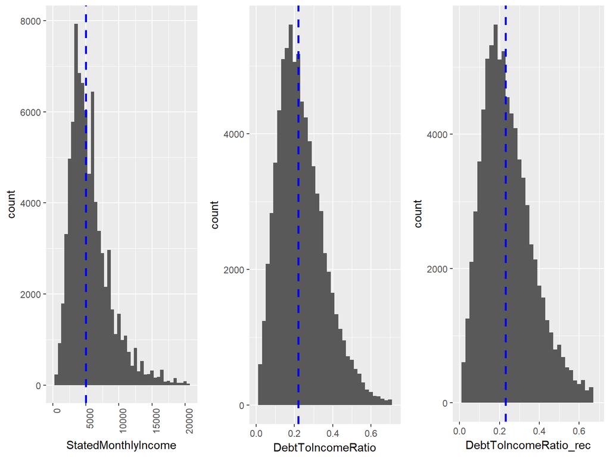

##### I will log transform the StatedMonthlyIncome and DebtToIncomeRatio_rec to get more normal distributions and to better understand their distributions.

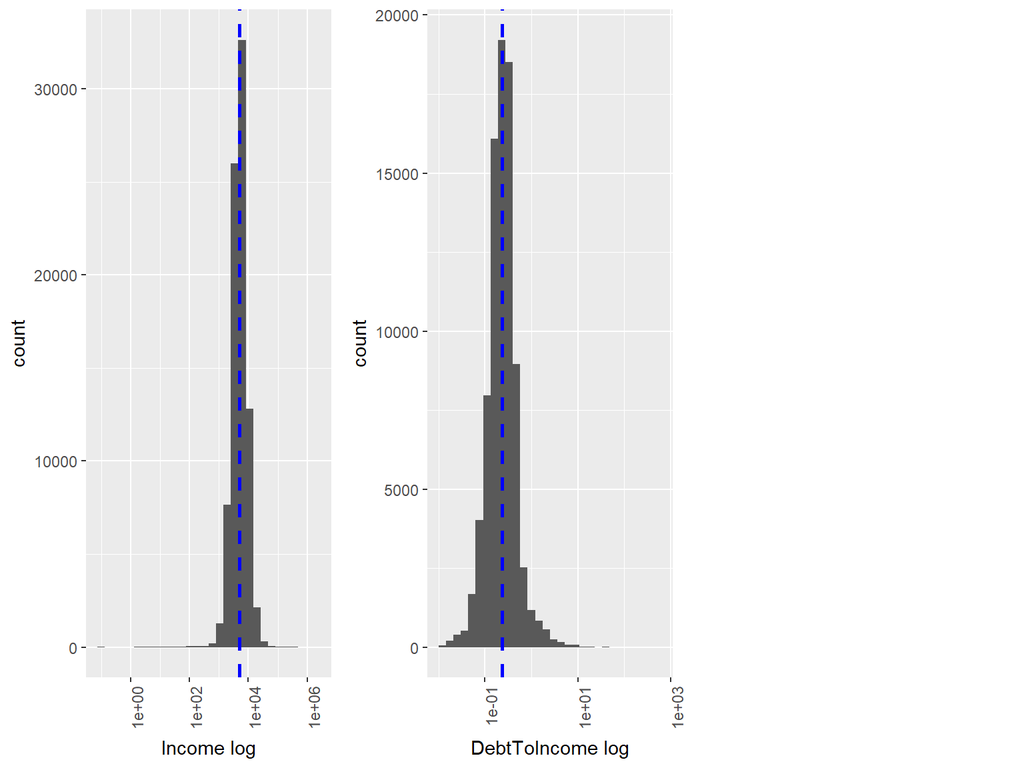

### 8. LISTING CATEGORY

##### The purpose of the loanS was mainly debt consolidation.

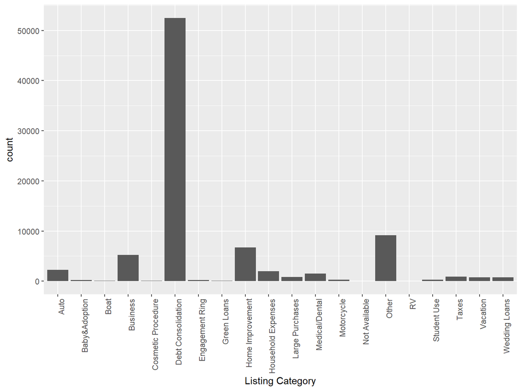

## Univariate Analysis

### What is the structure of your dataset?

##### The initial dataset has 113937 obervations and 81 variables.

##### After cleaning the table as explained in the dedicated section above, I reduced dimension of the table to 83982 rows.

### What is/are the main feature(s) of interest in your dataset?

##### I’m especially interested in the borrowers’ characteristics like: Income, borrower rate, debt to income etc., how are these variables influencing the prosper score and also, what is the evolution in time of the number/amount of loans, or of the financial indicators.

### What other features in the dataset do you think will help support your investigation into your feature(s) of interest?

##### I will also take into consideration:

##### -Term,

##### -BankcardUtilization,

##### -Available Bankcard Credit,

##### -Current Credit Lines,

##### -Open Revolving Accounts

### Did you create any new variables from existing variables in the dataset?

##### I created a new variable named Score. This variable takes values from ProsperRating..Alpha. or CreditGrade, so in the end we have a valid value for each borrower.

##### Also, I created variables for month, year, month&year from the loan origination date.

### Of the features you investigated, were there any unusual distributions? Did you perform any operations on the data to tidy, adjust, or change the form of the data? If so, why did you do this?

##### I log transformed the StatedMonthlyIncome and DebtToIncomeRatio_rec. These features are highly positively skewed and I transformed them to show a more normal distribution.

## Bivariate Plots Section

### 1. HOW MANY LOANS BY PROSPER SCORE AND YEAR?

##### Aggregate data by year and score, calculate absolute counts and percents, then plot the data.

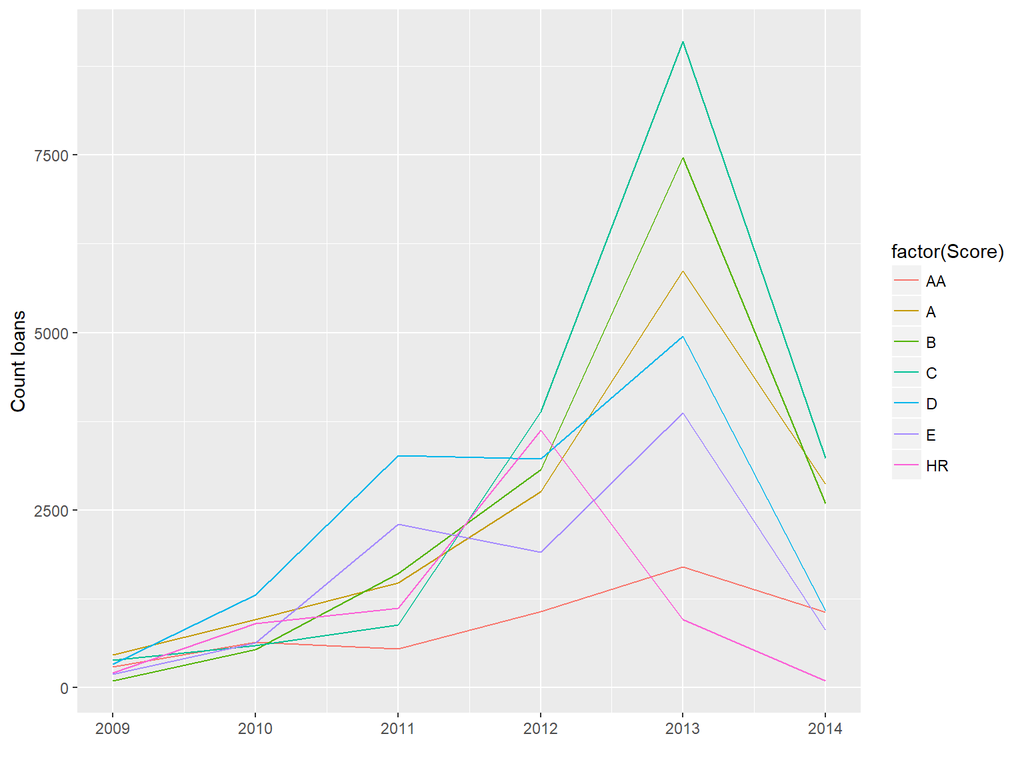

##### 2014 is deceiving as it contains data for only 3 months, so the plot shows a decreasing trend in 2014.

##### A solution would be to plot loans as % from total of each year.

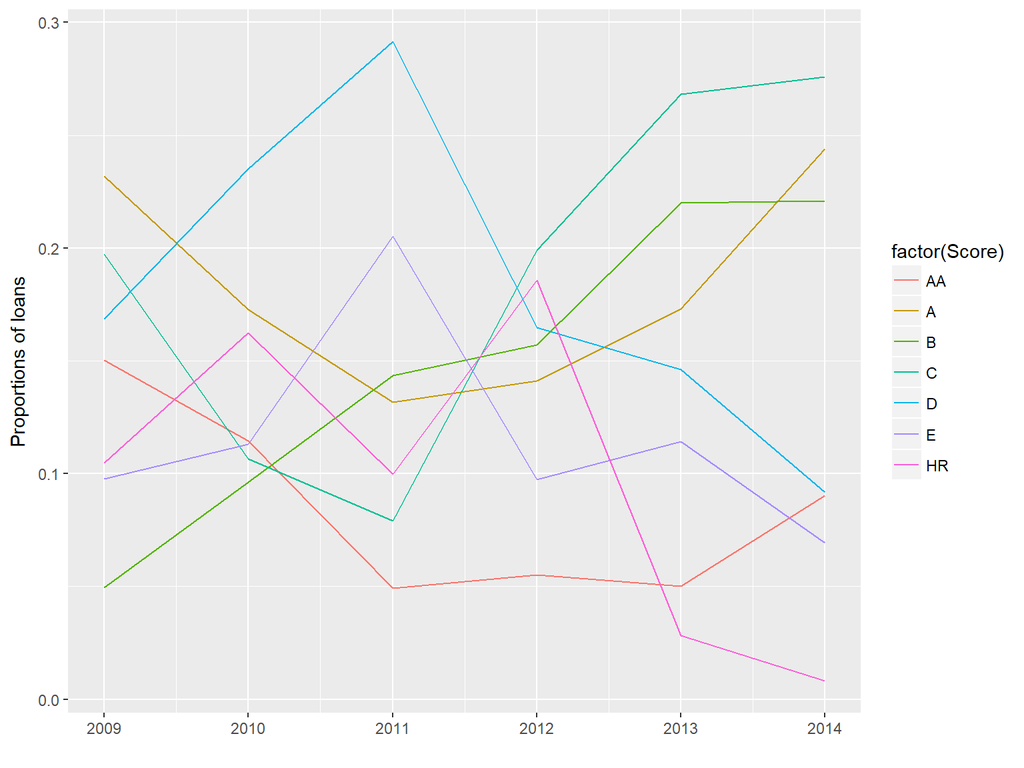

##### It looks like the number of loans in A,B,C categories have an ascending trend, while D,E,HR tend to descrease over time.

### 2. LOAN AMOUNT BY PROSPER SCORE AND YEAR

##### I will apply the same transformation as above and plot the proportions.

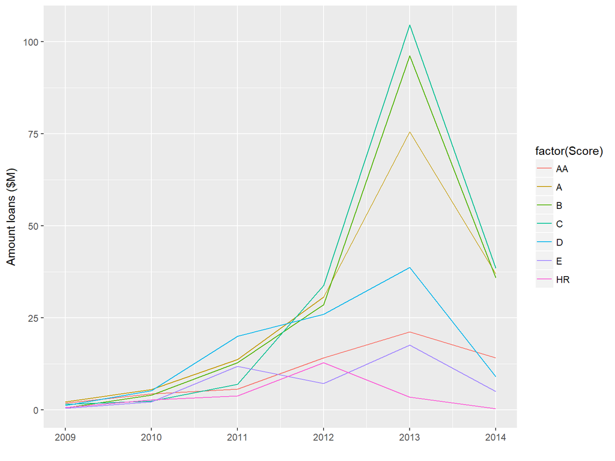

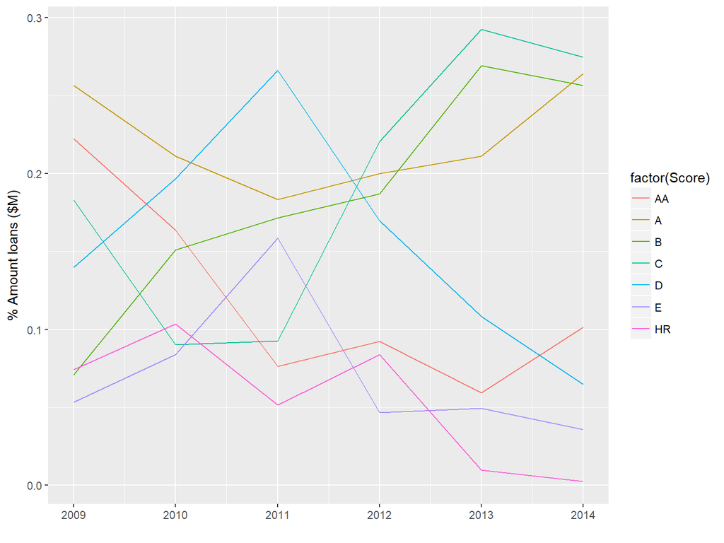

### 3.BOXPLOTS - LOAN AMOUNT BY PROSPER RATING

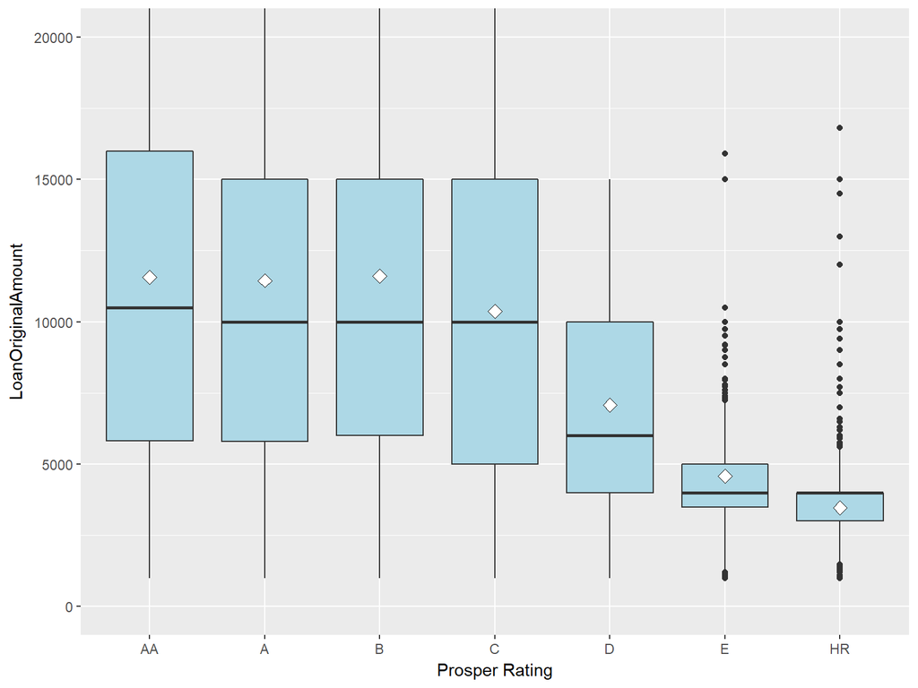

##### We notice lower loan values for high risk clients E and HR.

##### HR has negative skewed distribution.

```
##
##  Pearson's product-moment correlation
##
## data:  ProsperRating..numeric. and LoanOriginalAmount
## t = 137.71, df = 83980, p-value < 2.2e-16
## alternative hypothesis: true correlation is not equal to 0
## 95 percent confidence interval:
##  0.4236691 0.4347039
## sample estimates:
##       cor
## 0.4292025
```

##### There is a week positive association of 0.43 between loan amount and prosper score.

### 4. RELATIONSHIP BETWEEN LOAN AMOUNT ANF BORROWER RATE

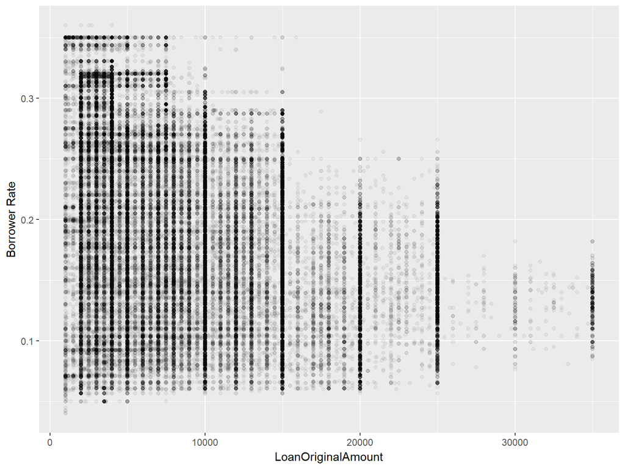

##### Borower rate is higher for small loans and descreases as loans increase.

##### Looks like there is a correlation between these two variable. Let’s see the Pearson’s correlation.

```
##
##  Pearson's product-moment correlation
##
## data:  BorrowerRate and LoanOriginalAmount
## t = -131.64, df = 83980, p-value < 2.2e-16
## alternative hypothesis: true correlation is not equal to 0
## 95 percent confidence interval:
##  -0.4191876 -0.4079748
## sample estimates:
##        cor
## -0.4135969
```

##### There is a week negative association of -0.41 between loan amount and borrower rate.

### 5. HOW ARE LOAN AMOUNT AND TERM RELATED? LARGER AMOUNTS ARE MADE ON LONGER TERMS?

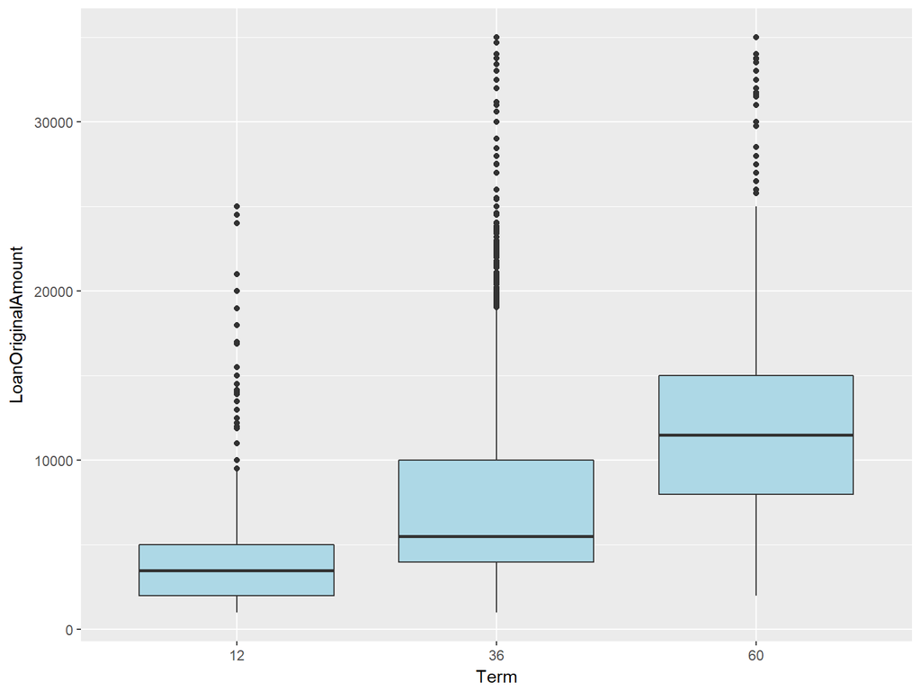

##### Loan terms are 12/36/60 months.For small amounts of money, the loans are made on 12 months term. As the loans amount increase, the term is also increasing.

### 6. WHAT IS THE RELATIONSHIP BETWEEN TERM AND BORROWER RATE?

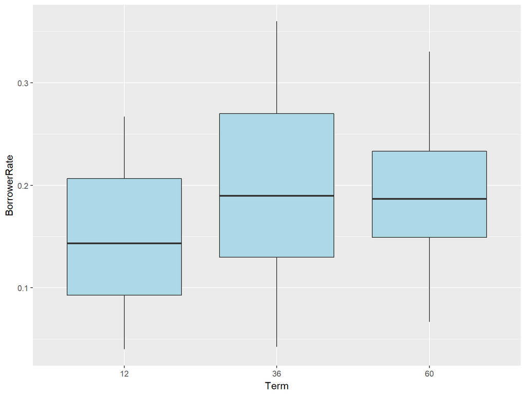

##### The highest borrower rates are for 36 months loans. Is it because most of loans are made on 36 months term?

##### Table of term:

```
##
##    12    36    60
##  1613 58141 24228
```

##### Yes, most of the loans are on 36 month term.

##### Is there a correlation between borrower rate and term?

```
##
##  Pearson's product-moment correlation
##
## data:  Term and BorrowerRate
## t = -0.097424, df = 83980, p-value = 0.9224
## alternative hypothesis: true correlation is not equal to 0
## 95 percent confidence interval:
##  -0.007099431  0.006427089
## sample estimates:
##           cor
## -0.0003361864
```

##### No correlation.

### 7. MONTHLY INCOME AND PROSPER RATING. DOES A HIGH INCOME ALSO MEAN A BETTER PROSPER SCORE?

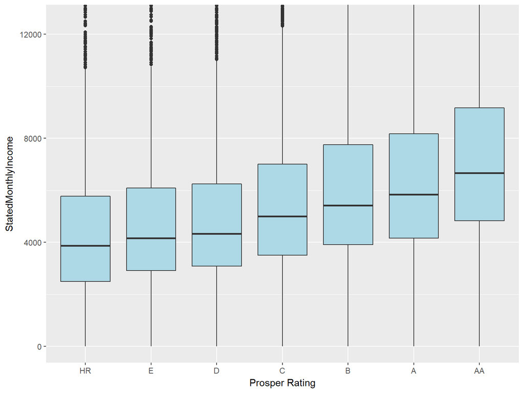

##### There are better Prosper scores for higher incomes.The income medians are increasing as the score gets better.

##### Is there any correlation between income and score?

```
##
##  Pearson's product-moment correlation
##
## data:  ProsperRating..numeric. and StatedMonthlyIncome
## t = 27.396, df = 83980, p-value < 2.2e-16
## alternative hypothesis: true correlation is not equal to 0
## 95 percent confidence interval:
##  0.08740874 0.10081545
## sample estimates:
##        cor
## 0.09411636
```

###### No correlation.

### 8. INCOME RANGE AND PROSPER RATING

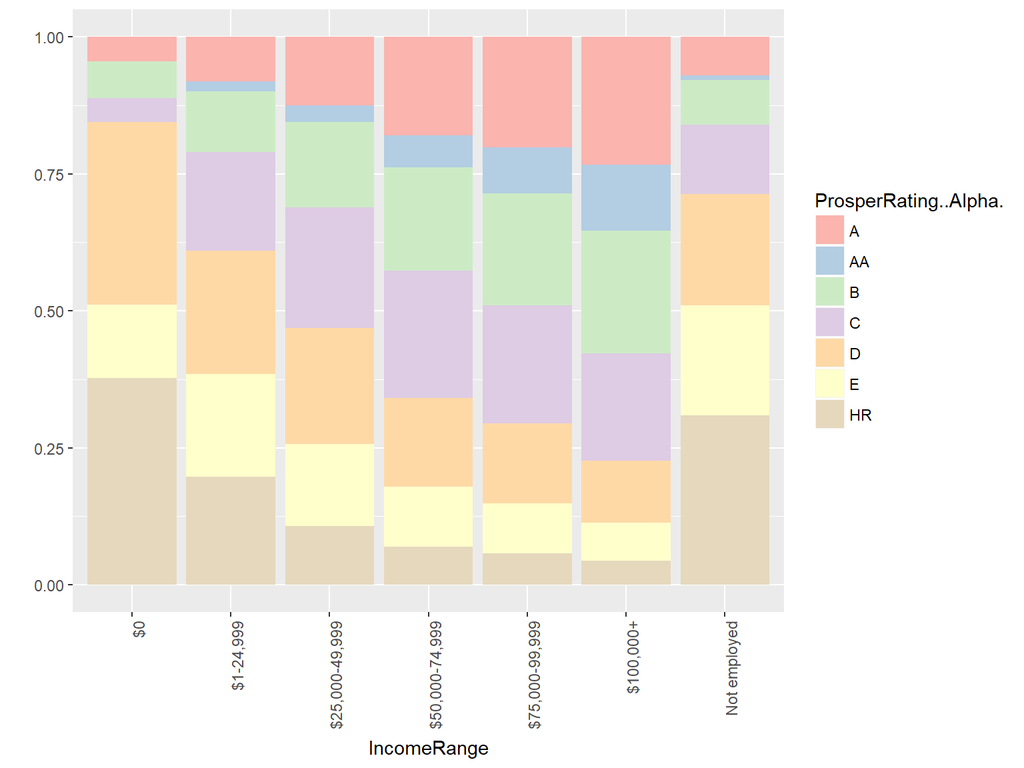

##### Those with undeclared income ($0 or NA) are scored worse, mostly in HR, E and D category.

##### As the income increses, the A,AA,B proportions also increase. D,E,HR proportions increase as the income decrease.

### 9. DEBT TO INCOME RATIO AND PROSPER SCORE

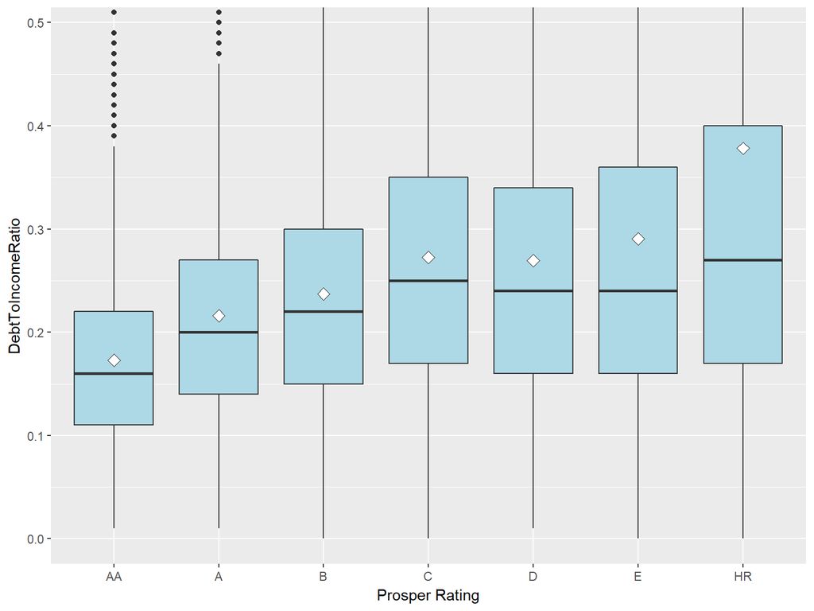

##### Worse scores for those with high Debt To Income Ratio.

##### Is there any correlations between score and debt to income ratio?

```
##
##  Pearson's product-moment correlation
##
## data:  ProsperRating..numeric. and DebtToIncomeRatio
## t = -37.845, df = 76766, p-value < 2.2e-16
## alternative hypothesis: true correlation is not equal to 0
## 95 percent confidence interval:
##  -0.1422738 -0.1283851
## sample estimates:
##        cor
## -0.1353361
```

##### No correlation.

### 10. LISTING CATEGORY BY SCORE

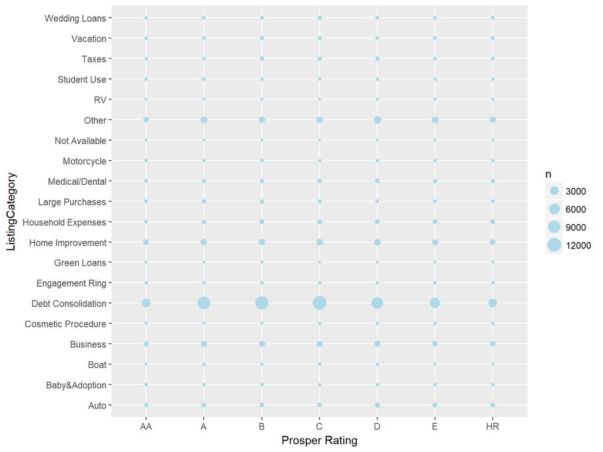